# Module 3: GLM and Logistic Regression

Sanchi Gupta, ALY6015 Intermediate Analytics

2024-01-28

# Introduction

The dataset from the ISLR library offers a comprehensive view of such factors, allowing for an exploratory dive into characteristics that distinguish private and public institutions. This report utilizes descriptive statistics and visualizations to unearth patterns and relationships within the dataset. Initially, the dataset is imported, and libraries essential for analysis are loaded. Subsequent descriptive analysis includes a summary table and various plots, such as scatter and box plots, illustrating the relationships between different variables such as student/faculty ratios and graduation rates. The analytical journey is further enriched by employing logistic regression to model the probability of a college being private, followed by an evaluation of the model’s performance using confusion matrices and ROC curves. The insights derived from this analysis aim to provide a nuanced understanding of the factors influencing the private and public sectors of higher education.

## 1. Import the data set and perform Exploratory Data Analysis by using descriptive statistics and plots to describe the data set

### **a. Importing the data set and required libraries.**

- **Importing libraries**

```r
library(ISLR)
library(caret)
```

```r
library(ggplot2)
library(pROC)
library(corrplot)
library(knitr)
library(kableExtra)
library(dplyr)
```

- **Importing the dataset**

```r
data("College")
```

### **b. Exploratory Data Analysis**

- **Descriptive Analysis**

```r
# Viewing Summary
college_summary <- summary(College)
kable(college_summary,
      format = "html",
      caption = "Table 1: Summary Statistics of College Dataset") %>%
                         kable_styling(bootstrap_options = c("striped", "hover", "condensed",                                                               "responsive"))
```

Table 1: Summary Statistics of College Dataset

|  | Private | Apps | Accept | Enroll | Top10perc | Top25perc | F.Undergrad | P.Undergrad | Outstate | Room.Board | Books | Personal | PhD | Terminal | S.F.Ratio | perc.alumni | Expend | Grad.Rate |
| --- | --- | --- | --- | --- | --- | --- | --- | --- | --- | --- | --- | --- | --- | --- | --- | --- | --- | --- |
|  | No :212 | Min. : 81 | Min. : 72 | Min. : 35 | Min. : 1.00 | Min. : 9.0 | Min. : 139 | Min. : 1.0 | Min. : 2340 | Min. :1780 | Min. : 96.0 | Min. : 250 | Min. : 8.00 | Min. : 24.0 | Min. : 2.50 | Min. : 0.00 | Min. : 3186 | Min. : 10.00 |
|  | Yes:565 | 1st Qu.: 776 | 1st Qu.: 604 | 1st Qu.: 242 | 1st Qu.:15.00 | 1st Qu.: 41.0 | 1st Qu.: 992 | 1st Qu.: 95.0 | 1st Qu.: 7320 | 1st Qu.:3597 | 1st Qu.: 470.0 | 1st Qu.: 850 | 1st Qu.: 62.00 | 1st Qu.: 71.0 | 1st Qu.:11.50 | 1st Qu.:13.00 | 1st Qu.: 6751 | 1st Qu.: 53.00 |
|  | NA | Median : 1558 | Median : 1110 | Median : 434 | Median :23.00 | Median : 54.0 | Median : 1707 | Median : 353.0 | Median : 9990 | Median :4200 | Median : 500.0 | Median :1200 | Median : 75.00 | Median : 82.0 | Median :13.60 | Median :21.00 | Median : 8377 | Median : 65.00 |
|  | NA | Mean : 3002 | Mean : 2019 | Mean : 780 | Mean :27.56 | Mean : 55.8 | Mean : 3700 | Mean : 855.3 | Mean :10441 | Mean :4358 | Mean : 549.4 | Mean :1341 | Mean : 72.66 | Mean : 79.7 | Mean :14.09 | Mean :22.74 | Mean : 9660 | Mean : 65.46 |
|  | NA | 3rd Qu.: 3624 | 3rd Qu.: 2424 | 3rd Qu.: 902 | 3rd Qu.:35.00 | 3rd Qu.: 69.0 | 3rd Qu.: 4005 | 3rd Qu.: 967.0 | 3rd Qu.:12925 | 3rd Qu.:5050 | 3rd Qu.: 600.0 | 3rd Qu.:1700 | 3rd Qu.: 85.00 | 3rd Qu.: 92.0 | 3rd Qu.:16.50 | 3rd Qu.:31.00 | 3rd Qu.:10830 | 3rd Qu.: 78.00 |
|  | NA | Max. :48094 | Max. :26330 | Max. :6392 | Max. :96.00 | Max. :100.0 | Max. :31643 | Max. :21836.0 | Max. :21700 | Max. :8124 | Max. :2340.0 | Max. :6800 | Max. :103.00 | Max. :100.0 | Max. :39.80 | Max. :64.00 | Max. :56233 | Max. :118.00 |

The table displays summary statistics for various columns in the college dataset. For instance, **‘Private’** is a categorical variable indicating whether the college is private (yes) or public (no). There are 212 public colleges and 565 private colleges represented in the dataset.

- **Scatter Plot for University type**

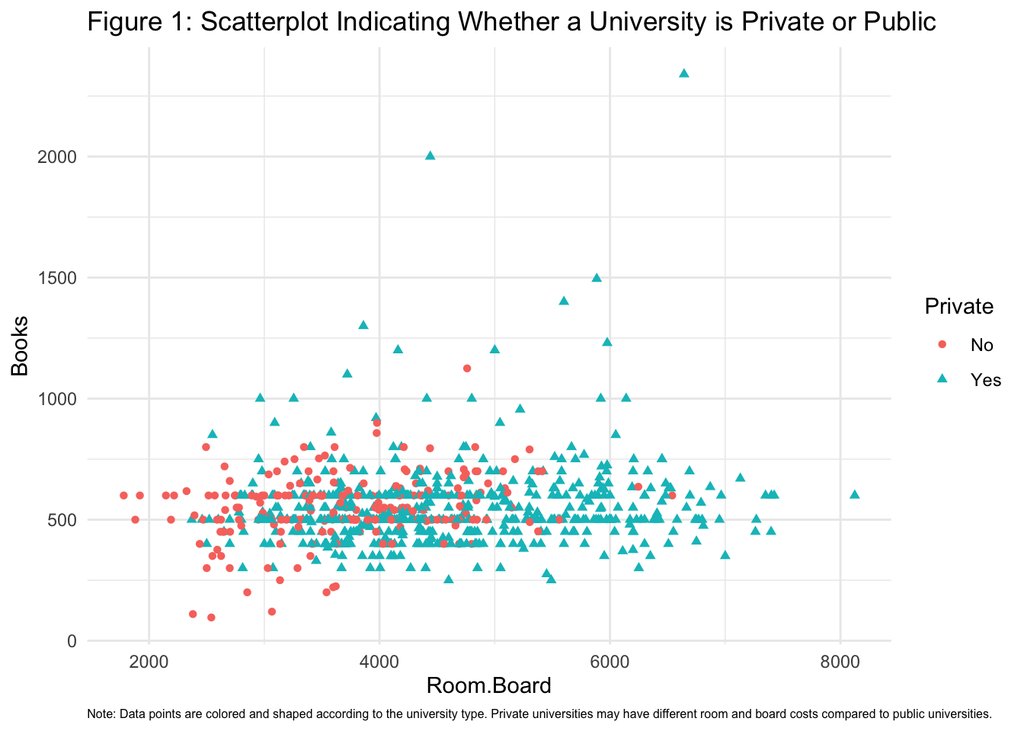

  ```r
  # Scattarplot for indicating whether a college is private or public
  qplot(x = Room.Board, y = Books, color = Private, shape= Private ,geom = 'point', data = College)+
    labs(title = "Figure 1: Scatterplot Indicating Whether a University is Private or Public",
         caption = "Note: Data points are colored and shaped according to the university type. Private universities may have different room and board costs compared to public universities.") +
    theme_minimal()  +
    theme(plot.caption = element_text(hjust = 0, size = 6))
  ```

**Interpretation of Figure 1: Scatter Plot Indicating Whether a University is Private or Public**

This scatterplot provides a visual representation that could help in identifying cost-related trends between private and public universities, but it also indicates that there is a significant overlap in the costs associated with both types of institutions.

- **Box Plot indicating Graduation Rates by College**

[figure not shown]

**Interpretation of Figure 2: Box Plot of Graduation Rates by College Type**

This boxplot compares the graduation rates (%) between two groups: colleges labeled “no” (public) and “yes” (private). We can observe that private colleges generally have a higher median graduation rate than public colleges. There is a greater spread in the graduation rates of private colleges, suggesting more diversity in outcomes. Both private and public colleges have outliers, indicating some colleges have unusually high or low graduation rates compared to their respective groups.

- **Box Plot indicating Student/Faculty ratio by College**

[figure not shown]

- **Correlation Matrix**

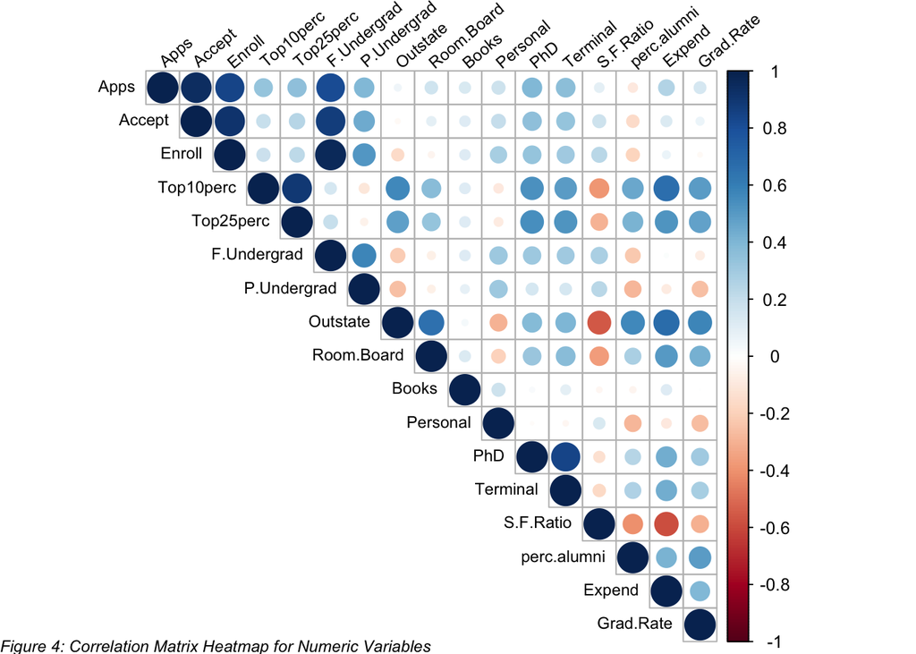

```r
# Correlation matrix for numeric variables
numeric_extract <- College %>% select(-c(Private))

# Calculating correlation matrix
correlation_table <- cor(numeric_extract, use = "complete.obs")

# Plotting correlation matrix
corrplot(correlation_table,
         method = "circle",
         type = "upper",
         tl.col = "black",
         tl.srt = 40,
         tl.cex = 0.75,
         addrect = 3)

# Adding caption below the plot
mtext("Figure 4: Correlation Matrix Heatmap for Numeric Variables", side = 1, line = 4.2, cex = 0.75, adj = 0, font = 3)
```

**Interpretation of Figure 4: Correlation Matrix Heatmap**

The above correlation matrix is used to represent the correlation coefficients between pairs of variables in a dataset. Each cell in the heatmap corresponds to the correlation between the variables on the x and y axes. For instance, as shown above, variables such as ‘F.undergrad’ and ‘Enroll’ seem to have a strong positive correlation (dark blue), which is logical as colleges with more full-time undergraduates would likely have higher enrollment numbers.

## 2. Split the data into a train and test set

```r
set.seed(123)
train_index <- createDataPartition(College$Private, p=0.7, list = FALSE)
train <- College[train_index,]
test <- College[-train_index,]
# (Code Sorced from Canvas- Lab: Logistic Regression)
```

## 3. Fit logistic regression model

```r
model_1 <- glm(Private ~. , data= train, family= binomial)
summary(model_1)
```

```
##
## Call:
## glm(formula = Private ~ ., family = binomial, data = train)
##
## Coefficients:
##               Estimate Std. Error z value Pr(>|z|)
## (Intercept) -0.3837441  2.5287015  -0.152  0.87938
## Apps        -0.0005226  0.0003089  -1.692  0.09070 .
## Accept       0.0003383  0.0006281   0.539  0.59019
## Enroll       0.0017904  0.0012618   1.419  0.15592
## Top10perc    0.0127635  0.0370418   0.345  0.73042
## Top25perc    0.0053642  0.0267867   0.200  0.84128
## F.Undergrad -0.0007627  0.0002739  -2.785  0.00536 **
## P.Undergrad  0.0002173  0.0002614   0.831  0.40573
## Outstate     0.0007750  0.0001624   4.773 1.82e-06 ***
## Room.Board  -0.0000698  0.0003345  -0.209  0.83472
## Books        0.0024696  0.0018723   1.319  0.18716
## Personal    -0.0003566  0.0003468  -1.028  0.30382
## PhD         -0.0539319  0.0345821  -1.560  0.11887
## Terminal    -0.0401208  0.0336091  -1.194  0.23258
## S.F.Ratio   -0.0625279  0.0939568  -0.665  0.50573
## perc.alumni  0.0354363  0.0281107   1.261  0.20745
## Expend       0.0001801  0.0001780   1.012  0.31163
## Grad.Rate    0.0271715  0.0177348   1.532  0.12550
## ---
## Signif. codes:  0 '***' 0.001 '**' 0.01 '*' 0.05 '.' 0.1 ' ' 1
##
## (Dispersion parameter for binomial family taken to be 1)
##
##     Null deviance: 639.40  on 544  degrees of freedom
## Residual deviance: 145.98  on 527  degrees of freedom
## AIC: 181.98
##
## Number of Fisher Scoring iterations: 8
```

The model seems to fit the data well since the residual deviance has decreased substantially from the null deviance. ‘Outstate’ and ‘F.Undergrad’ appear to be important predictors in determining whether a university is private or not, with tuition fees for out-of-state students increasing the likelihood of a university being private, and a larger number of full-time undergraduates decreasing this likelihood.

## 4. Create a confusion matrix and report the results of your model predictions on the train set. Interpret and discuss the confusion matrix. Which misclassifications are more damaging for the analysis, False Positives or False Negatives?

```r
# Building predictive model for train dataset
prob.train <- predict(model_1, newdata = train, type = "response")

predicted.min <- as.factor(ifelse(prob.train>= 0.5, "Yes", "No"))

# Creating Confusion Matrix for train dataset
train_matrix <- confusionMatrix(predicted.min, train$Private, positive = 'Yes')

print(train_matrix)
```

```
## Confusion Matrix and Statistics
##
##           Reference
## Prediction  No Yes
##        No  137  11
##        Yes  12 385
##
##                Accuracy : 0.9578
##                  95% CI : (0.9373, 0.9731)
##     No Information Rate : 0.7266
##     P-Value [Acc > NIR] : <2e-16
##
##                   Kappa : 0.8936
##
##  Mcnemar's Test P-Value : 1
##
##             Sensitivity : 0.9722
##             Specificity : 0.9195
##          Pos Pred Value : 0.9698
##          Neg Pred Value : 0.9257
##              Prevalence : 0.7266
##          Detection Rate : 0.7064
##    Detection Prevalence : 0.7284
##       Balanced Accuracy : 0.9458
##
##        'Positive' Class : Yes
##
```

```r
# (Code Sorced from Canvas- Lab: Logistic Regression)
```

**Discussion of Confusion Matrix:**

**Q: Which misclassifications are more damaging for the analysis, False Positives or False Negatives?**

**A:** The classification of which is more damaging (FP or FN) depends on the context of the analysis. If the ‘Yes’ class represents private universities and the analysis is for resource allocation, then false negatives might be more damaging because they represent private universities that are not identified as such, potentially leading to a misallocation of resources. Conversely, if the ‘Yes’ class represents universities requiring interventions due to poor performance, then false positives might be more damaging as they represent resources being unnecessarily allocated to universities that do not need them.

## 5. Report and interpret Accuracy, Precision, Recall, and Specificity metrics

**Interpretation of Confusion Matrix for train set:**

- **Accuracy:**
  - **Reported Value:** 0.9578 (or 95.78%)
  - **Interpretation:** The accuracy indicates that approximately 95.78% of all predictions made by the model are correct.
- **Precision (Positive Predictive Value):**
  - **Reported Value:** 0.9698 (or 96.98%)
  - **Interpretation:** This measures the model’s ability to correctly predict positive observations out of all observations it predicted as positive. In this case, when the model predicts a university as private, it is correct about 96.98% of the time.
- **Recall (Sensitivity):**
  - **Reported Value:** 0.9722 (or 97.22%)
  - **Interpretation:** Recall quantifies the model’s ability to identify all actual positives. The recall of approximately 97.22% indicates that the model is excellent at correctly identifying private universities as private.
- **Specificity:**
  - **Reported Value:** 0.9195 (or 91.95%)
  - **Interpretation:** Specificity measures the model’s ability to correctly identify negative observations. With a specificity of around 91.95%, the model is also very good at correctly identifying public universities as public, although it’s slightly less effective compared to how it identifies private universities.

## 6. Create a confusion matrix and report the results of your model for the test set. Compare the results with the train set and interpret

```r
# Building predictive model for test dataset
prob.test <- predict(model_1, newdata = test, type = "response")

predicted.min <- as.factor(ifelse(prob.test>= 0.5, "Yes", "No"))

# Creating Confusion Matrix for test dataset
test_matrix <- confusionMatrix(predicted.min, test$Private, positive = 'Yes')

print(test_matrix)
```

```
## Confusion Matrix and Statistics
##
##           Reference
## Prediction  No Yes
##        No   55   5
##        Yes   8 164
##
##                Accuracy : 0.944
##                  95% CI : (0.9061, 0.9698)
##     No Information Rate : 0.7284
##     P-Value [Acc > NIR] : <2e-16
##
##                   Kappa : 0.8562
##
##  Mcnemar's Test P-Value : 0.5791
##
##             Sensitivity : 0.9704
##             Specificity : 0.8730
##          Pos Pred Value : 0.9535
##          Neg Pred Value : 0.9167
##              Prevalence : 0.7284
##          Detection Rate : 0.7069
##    Detection Prevalence : 0.7414
##       Balanced Accuracy : 0.9217
##
##        'Positive' Class : Yes
##
```

**Interpretation of Confusion Matrix for test set:**

- **Accuracy:**
  - **Reported Value:** 0.944 or 94.4%
  - **Interpretation:** A high proportion of the total predictions made by the model are correct, indicating it is performing well on the test set.
- **Precision (Positive Predictive Value):**
  - **Reported Value:** 0.9535 or 95.35%
  - **Interpretation:** When the model predicts a university as ‘Yes’ (private), it is correct 95.35% of the time. This high precision suggests there are relatively few false positives.
- **Recall (Sensitivity):**
  - **Reported Value:** 0.9704 or 97.04%
  - **Interpretation:** The model is very effective at identifying true ‘Yes’ cases. It correctly identifies 97.04% of all actual ‘Yes’ cases, indicating a high sensitivity.
- **Specificity:**
  - **Reported Value:** 0.8730 or 87.3%
  - **Interpretation:** The model correctly identifies 87.3% of the actual ‘No’ cases (presumably public universities). While slightly lower than the sensitivity, it still indicates a good ability to distinguish ‘No’ cases.

#### Comparison between Train Set and Test Set

[figure not shown]

```r
# Extract performance metrics for training set
train_metrics <- c( train_matrix$overall['Accuracy'],
                    train_matrix$byClass['Sensitivity'],
                    train_matrix$byClass['Specificity'],
                    train_matrix$byClass['Pos Pred Value']
)

# Extract performance metrics for test set
test_metrics <- c(test_matrix$overall['Accuracy'],
                    test_matrix$byClass['Sensitivity'],
                    test_matrix$byClass['Specificity'],
                    test_matrix$byClass['Pos Pred Value']
)

# Create a data frame for visualization
performance_matrix <- data.frame(
  Metric = rep(names(train_metrics), each = 2),
  Value = c(train_metrics, test_metrics),
  Dataset = factor(rep(c("Train Set", "Test Set"), times = length(train_metrics)))
)


# Create the line plot
ggplot(data = performance_matrix, aes(x = Metric, y = Value, group = Dataset, color = Dataset)) +
  geom_line() +
  geom_point(size = 3) +
  theme_minimal() +
  labs(title = "Figure 5: Performance Metrics: Train vs. Test Set",
       caption = "Note: Lines indicate performance metrics for training and test datasets. Blue represents the training set; red represents the test set.",
       x = "Metric",
       y = "Value") +
  scale_color_manual(values = c("Train Set" = "blue", "Test Set" = "red")) +
  theme(plot.caption = element_text(hjust = 0, size = 8))
```

## 7. Plot and interpret the ROC curve

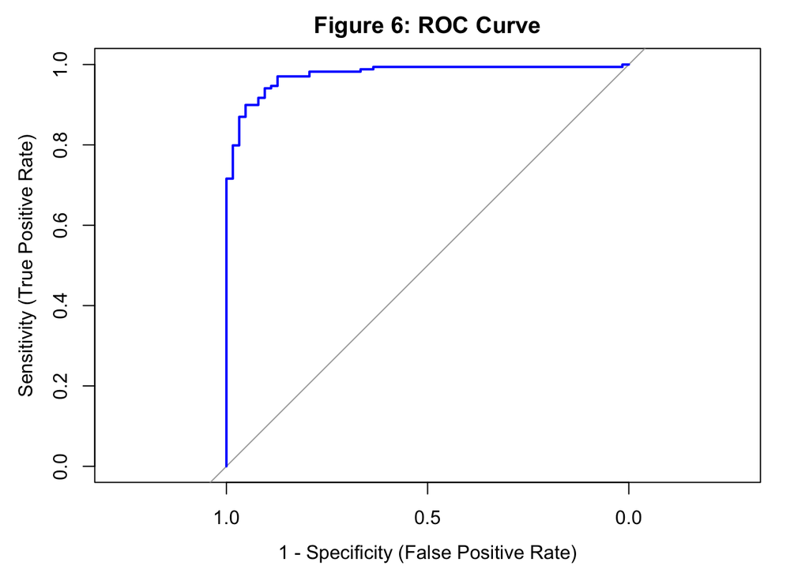

```r
# Generate the ROC curve object
roc_curve <- roc(test$Private, prob.test)
# Plot ROC curve
plot(roc_curve, main="Figure 6: ROC Curve",
     xlab="1 - Specificity (False Positive Rate)",
     ylab="Sensitivity (True Positive Rate)",
     col="blue")
```

```r
# (OpenAI, 2024)
```

**Interpretation of Figure 6: ROC Curve**

The diagonal grey line represents a no-skill classifier that does no better than random chance. The ROC curve’s significant deviation above this line indicates that the model has good discriminative ability.

## 8. Calculate and interpret the AUC

```r
# Calculate the area under the ROC curve (AUC)
auc(roc_curve)
```

```
## Area under the curve: 0.9753
```

**Interpretation of AUC:**

The AUC is a measure of the overall performance of a classification model. An AUC of 0.9753 is very close to 1, which is the maximum possible value. This indicates an excellent level of discrimination by the model, meaning it is very effective at distinguishing between the positive class and the negative class. This high AUC value often correlates with a high level of accuracy in predictions, though it’s always important to consider the AUC in the context of the specific application and the consequences of false positives and false negatives.

In summary, an AUC of 0.9753 suggests that the model has a high probability of ranking a randomly chosen positive instance (private university) higher than a randomly chosen negative instance (public university), in terms of the predicted probabilities of being positive.

## Conclusion

The analytical exploration of the College dataset has revealed significant insights into the factors that differentiate private and public colleges. Through a combination of logistic regression modeling and performance evaluation metrics, the analysis has demonstrated that variables such as out-of-state tuition and full-time undergraduate enrollment serve as significant predictors of a college’s private or public status. The high accuracy and AUC of the model suggest robust predictive capabilities, potentially guiding stakeholders in making informed decisions. While the study provides a solid foundation, it also opens avenues for further research, particularly in examining the causal relationships and long-term trends that might influence these educational institutions. The findings underscore the complexity and multifaceted nature of higher education systems, highlighting the importance of data-driven approaches in educational policy and administration.

## References

- *OpenAI. (2021). ChatGPT (Version 3.5). OpenAI.https://chat.openai.com/*
- Frasca. (n.d.). Lab: Logistic Regression Video [Video]. Panopto. Northeastern University